# Project 1: Biomedical & Clinical Informatics - Adventure 2

Merrimack College DSE6630: Healthcare & Life Sciences Analytics

Mike Steyer

28 May 2025

# Results:

- Two data sets have been analyzed in this demo & project - patients who had undergone surgical procedures and patients who were treated for pneumonia. The goal was to determine which set of data resulted in better model for predicting hospital readmission rates.
- Based on the analysis, it appears that the non-surgical group is a better prediction data set for readmission rates, but not by much. Both datasets result in models that perform poorly - high RMSE scores and low R^2 scores.

# Next Steps & Recommendations

- Further analysis may result in better results. Perhaps instead of framing the data in terms of illness, what if the ratings of hospitals & staff alone are used to build a predictive model of readmission?

# 1 - Introduction (Adventure 2)

**[More coding, but not as much, with a focus on the steps we’ve undertaken here and extending it to a new question & condition.]** Choose a slightly more complicated analysis to undertake, for example, focusing on surgical interventions (`HIP-KNEE` & `CABG`) or heart-related conditions (`HF`, `AMI`, & `CABG`). Coding should still be fairly minimal, but you are likely to run into problems with the code working exactly as-is, especially during cleaning. The advantage of this analysis is that it will be much more robust, have larger sample sizes, and would allow us to be able to say something far more informative to a subset of patients (e.g., those considering undergoing surgical interventions). See more information on Adventure 2 here.

- Make sure to update your filepath to where you stored the hospital files on YOUR local machine, just as you did in Question 1 of the Demo!
- Make sure to update the condition that gets selected from “PN” to the condition of your choosing. A full list of available conditions is found in Demo 1.
- Choose a slightly more complicated analysis to undertake, for example, focusing on surgical interventions (`HIP-KNEE` & `CABG`) or heart-related conditions (`HF`, `AMI`, & `CABG`).

You can avoid going back to Demo 1 to do your importing, cleaning, and pre-processing by running this source code:

```r
## Make any necessary changes in the R source code
## Uncomment to run!

source(file = "reRunDemoData.R")
```

```
## [1] "HF"
## [1] "CABG"
## [1] "AMI"
```

# 2 - Encoding

Perform the encoding for ordinal categorical columns. We need to encode these values into numerical equivalents to allow machine learning.

```r
## This calls the code in the associated .R file
source(file = "doOrdinalEncoding.R")

## This sets a list of PATTERNS to match for the columns to ordinal encode
encodeList <- c("ComparedToNational_",
                "PaymentCategory",
                "ValueOfCareCategory",
                "Score_Emergency department volume")

## This runs the function, which takes 3 arguments
## Open the source code to see what each argument does!
dat2Analyze <- doOrdinalEncoding(df = dataAnalyzeNoEncoding,
                                 encodeList = encodeList,
                                 quiet = FALSE)
```

# 3 - Summary Statistics of Potential Target Variables

Take a look at what’s available for the illnesses we are interested in and how valuable they are to analysis. We’ll be using the `PredictedReadmissionRate` variable as our target as it most aligns with the stakeholder request, but below we provide some analysis of the other target variables.

**Table 2. Possible target measure summaries**

| **Characteristic** | **N = 4,775**<sup>1</sup> |
| --- | --- |
| National Comparison Heart Attack Return Hospital Days |  |
| Better than average | 125 / 4,775 (2.6%) |
| Same as average | 1,237 / 4,775 (26%) |
| Worse than average | 219 / 4,775 (4.6%) |
| Unknown | 3,194 / 4,775 (67%) |
| National Comparison Heart Failure Return Hospital Days |  |
| Better than average | 296 / 4,775 (6.2%) |
| Same as average | 2,402 / 4,775 (50%) |
| Worse than average | 484 / 4,775 (10%) |
| Unknown | 1,593 / 4,775 (33%) |
| National Comparison CABG Readmission Rate |  |
| Better than average | 2 / 4,775 (<0.1%) |
| Same as average | 880 / 4,775 (18%) |
| Worse than average | 3 / 4,775 (<0.1%) |
| Unknown | 3,890 / 4,775 (81%) |
| Predicted Readmission Rate | 16.76 (2.51), 16.66 |
| (Missing) | 2,135 |
| Observed Readmission Rate | 18.3 (4.3), 17.8 |
| (Missing) | 2,433 |
| ExcessReadmissionRatio | 1.00 (0.05), 1.00 |
| (Missing) | 2,135 |
| Expected Readmission Rate | 16.71 (2.21), 16.47 |
| (Missing) | 2,135 |

<sup>1</sup> n / N (%); Mean (SD), Median

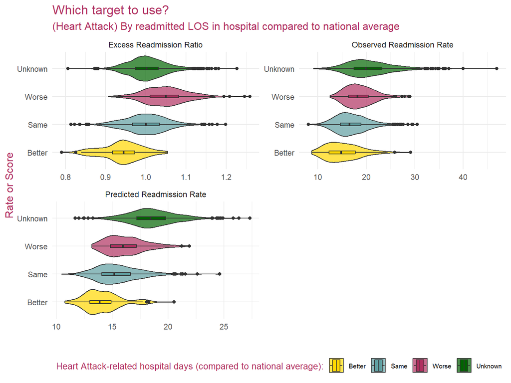

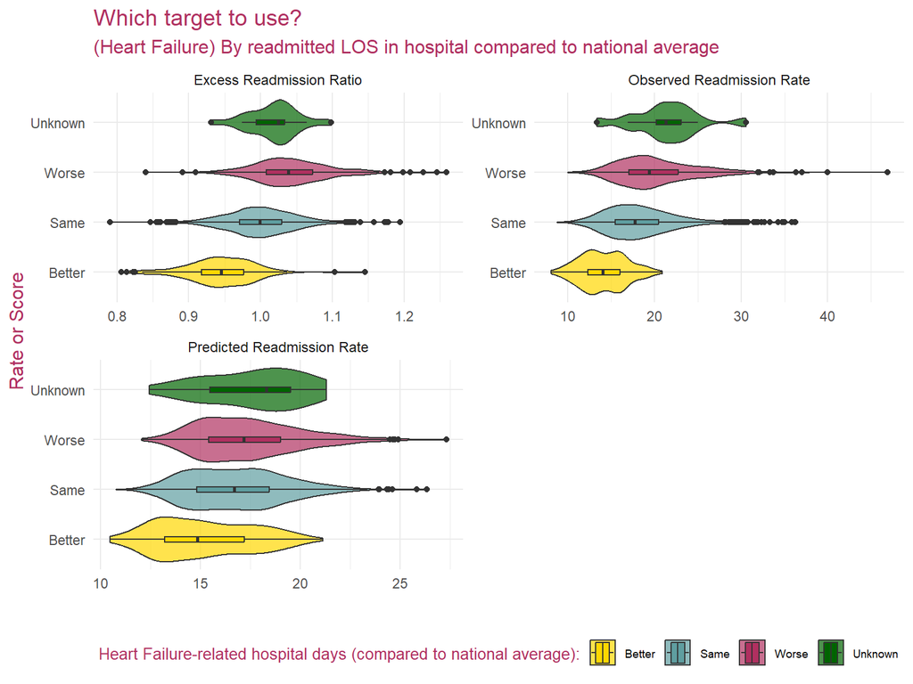

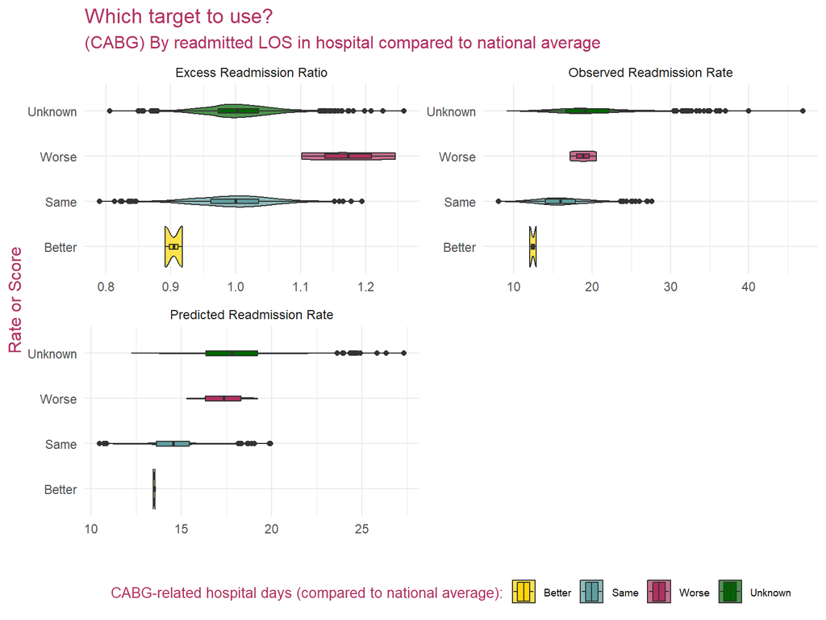

# 4 - Selecting Features

In this step we will remove unnecessary features from our data set in terms of predictive applicability to our target variable.

```r
## rewrite the `dat2Analyze` variable with the result of the following expression
dat2Analyze <- dat2Analyze %>%
  ## remove the columns we no longer care for (select 'except')
  select(-ExpectedReadmissionRate,
         -ExcessReadmissionRatio,
         -observed_readmission_rate,
         -contains(c("Sample_", "NumberOfPatients")),
         -NumberSurveysCompleted) %>%
  ## rename the columns to be more concise
  rename(`Median time (minutes) patients spent in ED` =
         `Score_Average (median) time patients spent in the emergency department before leaving from the visit A lower number of minutes is better`) %>%
  ## grab the target variable and all other columns
  select(PredictedReadmissionRate, everything())

## set the columns names of `dat2Analyze` as each column name with specific substrings removed
colnames(dat2Analyze) <- gsub('Score_|HcahpsLinearMeanValue_|_Payment', '', colnames(dat2Analyze))
```

Let’s take a look at the features with near-zero variance. These are prime targets for removal. In this data set, a lot of data is missing for the national comparison, and will result in these predictors being dropped.

Table 3. Columns dropped due to near-zero variance.

| Variables Dropped |
| --- |
| ComparedToNational_Death rate for heart attack patients |
| ComparedToNational_Death rate for stroke patients |
| ComparedToNational_Rate of readmission for CABG |

# 5 - Missingness Remidiation

Let’s detect what the missingness looks like across columns. Based on the results, all columns have some level of missingness.

```r
as.data.frame(
  colSums(is.na(dat2Analyze))
  ) %>%
  rename(
    "count_na" = `colSums(is.na(dat2Analyze))`
  ) %>%
  mutate(
    percent_na = (count_na / nrow(dat2Analyze)) * 100
  ) %>%
  arrange(desc(percent_na))
```

```
##                                                                                  count_na
## Rate of readmission for CABG                                                         3890
## ComparedToNational_Hospital return days for heart attack patients                    3194
## MRSA Bacteremia                                                                      3071
## ComparedToNational_MRSA Bacteremia                                                   3071
## Payment for heart attack patients                                                    2892
## PaymentCategory for heart attack patients                                            2892
## Death rate for heart attack patients                                                 2778
## Death rate for stroke patients                                                       2568
## PredictedReadmissionRate                                                             2135
## Medicare spending per patient                                                        1857
## Payment for heart failure patients                                                   1815
## PaymentCategory for heart failure patients                                           1815
## Death rate for heart failure patients                                                1645
## ComparedToNational_Death rate for heart failure patients                             1645
## Nurse communication                                                                  1601
## Doctor communication                                                                 1601
## Staff responsiveness                                                                 1601
## Communication about medicines                                                        1601
## Discharge information                                                                1601
## Care transition                                                                      1601
## Cleanliness                                                                          1601
## Quietness                                                                            1601
## Overall hospital rating                                                              1601
## Recommend hospital                                                                   1601
## ComparedToNational_Hospital return days for heart failure patients                   1593
## Percentage of healthcare personnel who are up to date with COVID-19 vaccinations     1287
## Left before being seen                                                                915
## Emergency department volume                                                           913
## Abdomen CT Use of Contrast Material                                                   865
## SurveyResponseRate                                                                    786
## Median time (minutes) patients spent in ED                                            740
## Healthcare workers given influenza vaccination                                        534
## State                                                                                 182
##                                                                                  percent_na
## Rate of readmission for CABG                                                      81.465969
## ComparedToNational_Hospital return days for heart attack patients                 66.890052
## MRSA Bacteremia                                                                   64.314136
## ComparedToNational_MRSA Bacteremia                                                64.314136
## Payment for heart attack patients                                                 60.565445
```

[output cut: 13 more lines]

```
## Discharge information                                                             33.528796
## Care transition                                                                   33.528796
## Cleanliness                                                                       33.528796
## Quietness                                                                         33.528796
## Overall hospital rating                                                           33.528796
## Recommend hospital                                                                33.528796
## ComparedToNational_Hospital return days for heart failure patients                33.361257
## Percentage of healthcare personnel who are up to date with COVID-19 vaccinations  26.952880
## Left before being seen                                                            19.162304
## Emergency department volume                                                       19.120419
## Abdomen CT Use of Contrast Material                                               18.115183
## SurveyResponseRate                                                                16.460733
## Median time (minutes) patients spent in ED                                        15.497382
## Healthcare workers given influenza vaccination                                    11.183246
## State                                                                              3.811518
```

Next, we’ll use the MICE library, which will pair missing values with non-missing or missing values to derive some meaning from these relationships. The first table (Missing vs Responded) shows the correlations between missing values of one column to non-missing values of another. The second table (Missing vs Missing) shows the correlations between missing values of one column to missing values of another.

```r
## Drop State and analyze the pairwise missingness using the mice package
miceMatrix <- dat2Analyze %>% select(-State) %>% md.pairs()

miceMatrix$mr[1:6, 1:10] %>%
  kable(format = "html",
    caption = "Table 4. Missing vs. Reponded Matrix Slice") %>%
    kable_styling(bootstrap_options = c("striped", full_width = F))
```

Table 4. Missing vs. Reponded Matrix Slice

|  | PredictedReadmissionRate | MRSA Bacteremia | Payment for heart attack patients | Payment for heart failure patients | Abdomen CT Use of Contrast Material | Death rate for heart attack patients | Death rate for heart failure patients | Death rate for stroke patients | Medicare spending per patient | Percentage of healthcare personnel who are up to date with COVID-19 vaccinations |
| --- | --- | --- | --- | --- | --- | --- | --- | --- | --- | --- |
| PredictedReadmissionRate | 0 | 37 | 20 | 372 | 1313 | 106 | 525 | 79 | 337 | 942 |
| MRSA Bacteremia | 973 | 0 | 357 | 1301 | 2219 | 460 | 1466 | 594 | 1258 | 1830 |
| Payment for heart attack patients | 777 | 178 | 0 | 1081 | 2043 | 115 | 1251 | 406 | 1090 | 1676 |
| Payment for heart failure patients | 52 | 45 | 4 | 0 | 984 | 90 | 178 | 10 | 368 | 786 |
| Abdomen CT Use of Contrast Material | 43 | 13 | 16 | 34 | 0 | 101 | 156 | 11 | 172 | 287 |
| Death rate for heart attack patients | 749 | 167 | 1 | 1053 | 2014 | 0 | 1138 | 389 | 1062 | 1647 |

```r
miceMatrix$mm[1:6, 1:10] %>%
  kable(format = "html",
    caption = "Table 5. Missing vs. Missing Matrix Slice") %>%
    kable_styling(bootstrap_options = c("striped", full_width = F))
```

Table 5. Missing vs. Missing Matrix Slice

|  | PredictedReadmissionRate | MRSA Bacteremia | Payment for heart attack patients | Payment for heart failure patients | Abdomen CT Use of Contrast Material | Death rate for heart attack patients | Death rate for heart failure patients | Death rate for stroke patients | Medicare spending per patient | Percentage of healthcare personnel who are up to date with COVID-19 vaccinations |
| --- | --- | --- | --- | --- | --- | --- | --- | --- | --- | --- |
| PredictedReadmissionRate | 2135 | 2098 | 2115 | 1763 | 822 | 2029 | 1610 | 2056 | 1798 | 1193 |
| MRSA Bacteremia | 2098 | 3071 | 2714 | 1770 | 852 | 2611 | 1605 | 2477 | 1813 | 1241 |
| Payment for heart attack patients | 2115 | 2714 | 2892 | 1811 | 849 | 2777 | 1641 | 2486 | 1802 | 1216 |
| Payment for heart failure patients | 1763 | 1770 | 1811 | 1815 | 831 | 1725 | 1637 | 1805 | 1447 | 1029 |
| Abdomen CT Use of Contrast Material | 822 | 852 | 849 | 831 | 865 | 764 | 709 | 854 | 693 | 578 |
| Death rate for heart attack patients | 2029 | 2611 | 2777 | 1725 | 764 | 2778 | 1640 | 2389 | 1716 | 1131 |

The heatmap describes correlation between missingness and a response across variables. A higher correlation (darker colors) indicates that the variable will provide more use during imputation than others.

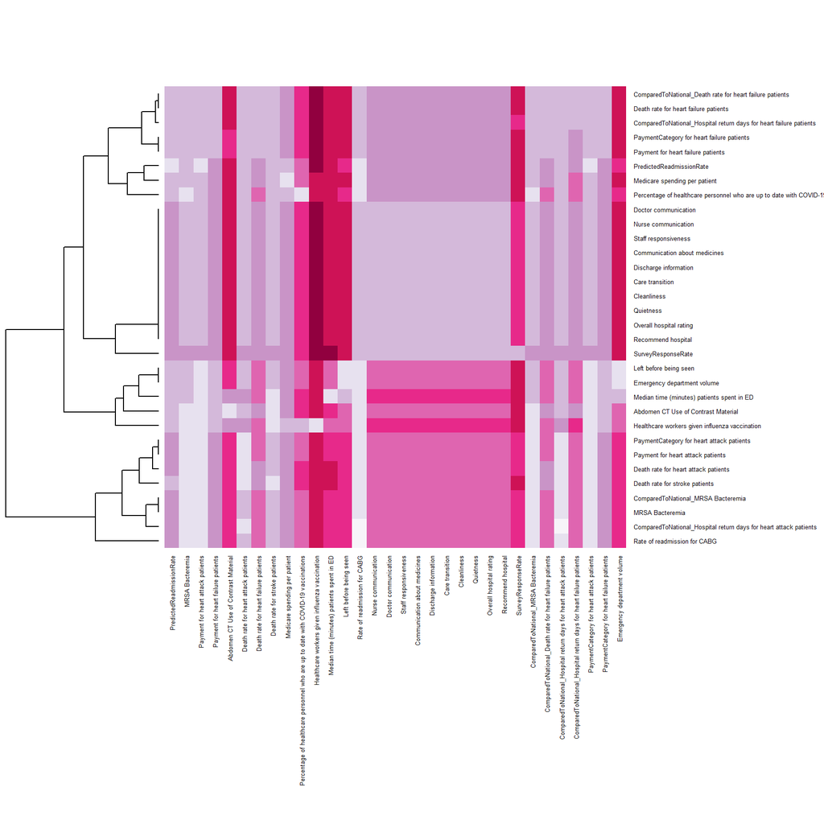

As the above heatmap analyzes all variables in the dataset to each other, we instead want to isolate to the target variable, `PredictedReadmissionRate`. We can see that the amount of missingness is substantial across many variables. We’ll include this in our final report as it will affect the validity of our model.

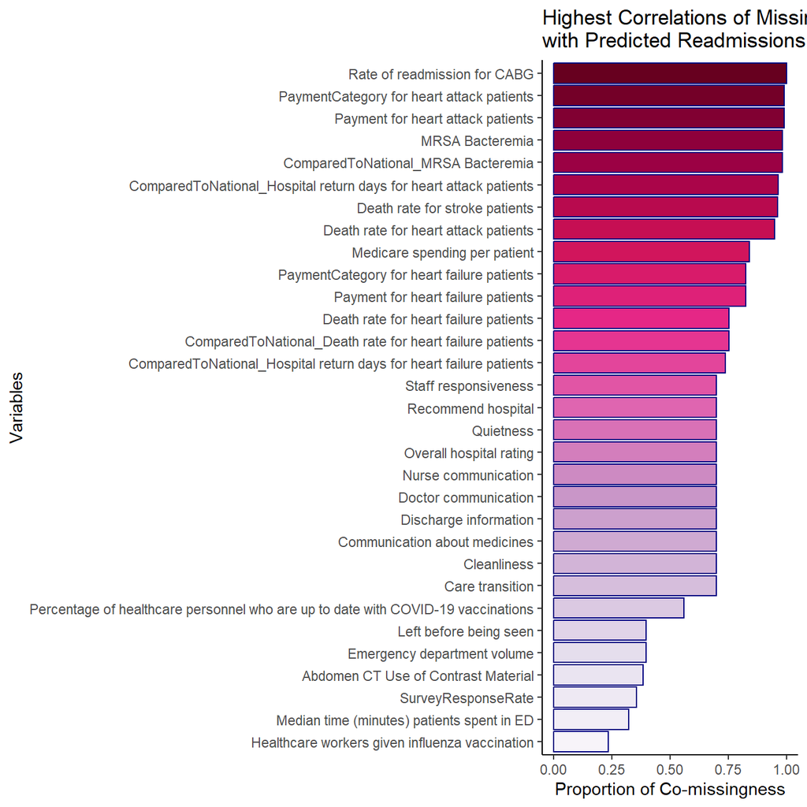

# 6 - Removal of NAs Here, we remove observations that have a NA value for our target variable, as they will not do anything to help the model’s accuracy. Although about half our rows are lost during this operation, our dimensionality ratio is still within tolerance.

```
## [1] "Rows: 2640"  "Columns: 33"
```

# 7 - Train / Test Data Splitting

Here, we define a function that can be used to calculate the ideal split ratio for our training & test data. We use it to generate our data partitions following the definition of the function.

```r
calcSplitRatio <- function(p = NA, df) {
  ## @p  = the number of parameters. by default, if none are provided, the number of columns (predictors) in the dataset are used
  ## @df = the dataframe that will be used for the analysis

  ## check if the number of predictors is defined
  if(is.na(p)) {
    p <- ncol(df) -1   ## the number of predictors was not defined, assign the number of columns-1 (-1 due to the exclusion of the target variable)
  }

  ## calculate the number of test rows to generate
  test_N <- (1/sqrt(p))*nrow(dat2Analyze)
  ## calculate the proportion of rows being used as test data
  test_prop <- round((1/sqrt(p))*nrow(dat2Analyze)/nrow(dat2Analyze), 2)
  ## calculate the proportion of rows being used as train data
  train_prop <- 1-test_prop

  ## write out the proportion to console
  print(paste0("The ideal split ratio is ", train_prop, ":", test_prop, " training:testing"))

  ## return the proportion of training data to use
  return(train_prop)
}

train_prop <- calcSplitRatio(df =dat2Analyze )
```

```
## [1] "The ideal split ratio is 0.82:0.18 training:testing"
```

```r
ind <- createDataPartition(dat2Analyze$PredictedReadmissionRate,
                           p = train_prop,
                           list = FALSE)

train <- dat2Analyze[ind, ]
test <- dat2Analyze[-c(ind), ]
```

# 8 - Imputation

We use the `missForest` library to generate mathematically probable values for our NAs in both our train & test data sets. The results of the imputation in the training set are in the table below.

```r
# Remove encoded categorical variables for imputation, plus the target and state (which have no missing)
data_sans_encoded = train %>%
  select(-PredictedReadmissionRate,
         -State,
         -`Emergency department volume`,
         -contains("ComparedToNational"))

data_cat = train %>%
  select(`Emergency department volume`,
         contains("ComparedToNational")) %>%
  mutate_all(as.factor)

# Stitch them back together:
temp <- cbind(data_sans_encoded, data_cat)

# Impute missing values using missForest
imputedTrain <- missForest(temp,
                          variablewise = TRUE,
                          verbose = FALSE)
```

```r
# Remove encoded categorical variables for imputation, plus the target and state (which have no missing)
data_sans_encoded = test %>%
  select(-PredictedReadmissionRate,
         -State,
         -contains("ComparedToNational"))

data_cat = test %>%
  select(contains("ComparedToNational")) %>%
  mutate_all(as.factor)

# Stitch them back together:
temp <- cbind(data_sans_encoded, data_cat)

# Impute missing values using missForest
imputedTest <- missForest(temp,
                          variablewise = TRUE,
                          verbose = FALSE)
```

Table 6. missForest OOB Error Rates for the imputed variables, training dataset

| OOB Error | Variable |
| --- | --- |
| **MSE** |  |
| 0.29 | MRSA Bacteremia |
| 2045434.72 | Payment for heart attack patients |
| 642411.34 | Payment for heart failure patients |
| 17.27 | Abdomen CT Use of Contrast Material |
| 1.36 | Death rate for heart attack patients |
| 1.99 | Death rate for heart failure patients |
| 3.04 | Death rate for stroke patients |
| 0.00 | Medicare spending per patient |
| 492.45 | Percentage of healthcare personnel who are up to date with COVID-19 vaccinations |
| 249.39 | Healthcare workers given influenza vaccination |
| 1335.12 | Median time (minutes) patients spent in ED |
| 9.08 | Left before being seen |
| 0.67 | Rate of readmission for CABG |
| 0.85 | Nurse communication |
| 1.75 | Doctor communication |
| 4.48 | Staff responsiveness |
| 3.92 | Communication about medicines |
| 4.33 | Discharge information |
| 1.28 | Care transition |
| 11.55 | Cleanliness |
| 13.02 | Quietness |
| 0.98 | Overall hospital rating |
| **PCF** |  |
| 2.46 | Recommend hospital |
| 0.00 | SurveyResponseRate |
| 0.05 | PaymentCategory for heart attack patients |
| 0.08 | PaymentCategory for heart failure patients |
| 0.48 | Emergency department volume |
| 0.13 | ComparedToNational_MRSA Bacteremia |
| 0.07 | ComparedToNational_Death rate for heart failure patients |
| 0.22 | ComparedToNational_Hospital return days for heart attack patients |
| 0.27 | ComparedToNational_Hospital return days for heart failure patients |

Very high error rates correspond to untrustworthy imputation results. We identify the following variables due to these high values (the list will be used later to remove these columns) - Payment for heart attack patients - Payment for heart failure patients - Recommend hospital - Emergency department volume

We also add the columns dropped during imputation back to the training and test sets.

```r
cols2drop <- c(
  "Payment for heart attack patients",
  "Payment for heart failure patients",
  "Recommend hospital",
  "Emergency department volume"
  )

imputedTrain <- imputedTrain$ximp %>%
  ## Put the original State and target variables back on
  mutate(State = train$State,
         PredictedReadmissionRate = train$PredictedReadmissionRate)

imputedTest <- imputedTest$ximp %>%
  ## Put the original State and target variables back on
  mutate(State = test$State,
         PredictedReadmissionRate = test$PredictedReadmissionRate)
```

Remove the untrustable imputed columns:

```r
imputedTrain <- imputedTrain[, !(names(imputedTrain) %in% cols2drop), drop = FALSE]
imputedTest  <- imputedTest[, !(names(imputedTest) %in% cols2drop), drop = FALSE]
```

# 9 - Converting data back to numeric values

The `missForest` package required some of our variables to be factors. However, we prefer numeric values for machine learning.

```r
readyTrain <- imputedTrain %>%
  mutate_if(is.factor, as.character) %>%
  mutate_if(is.character, as.numeric)

readyTest <- imputedTest %>%
  mutate_if(is.factor, as.character) %>%
  mutate_if(is.character, as.numeric)

## This calls the helper function in the associated .R file
source(file = "doFrequencyEncoding.R")

## If State is not already a number
if(!is.numeric(imputedTrain$State)) {
    ## This sets a list of COLUMN NAMES I want to frequency encode
    cols2encode <- c("State")

    ## This runs the function, which takes up to 4 arguments
    ## Open the source code to see what each argument does!
    ## It returns a LIST of frequency encoded dataframes.
    freqEncoded <- doFrequencyEncoding(train = imputedTrain,
                                       test = imputedTest,
                                       cols2encode = cols2encode,
                                       quiet = FALSE)

    ## Lastly, extract the newly encoded, imputed, dataframes!
    readyTrain <- freqEncoded$train
    readyTest <- freqEncoded$test
}
```

```
## [1] "Processing column State"
## [1] "Here's the encoder (store for your records):"
##
##   AK   AL   AR   AZ   CA   CO   CT   DC   DE   FL   GA   HI   IA   ID   IL   IN
##    6   43   29   43  195   37   22    3    2  135   60    9   18    9   84   56
##   KS   KY   LA   MA   MD   ME   MI   MN   MO   MS   MT   NC   ND   NE   NH   NJ
##   28   54   49   41   35   14   67   33   47   40   10   62    5   14   12   48
##   NM   NV   NY   OH   OK   OR   PA   RI   SC   SD   TN   TX   UT   VA   VT   WA
##   17   17  103   84   40   26   92    6   40    8   56  160   23   59    5   39
##   WI   WV   WY <NA>
##   49   19    6    9
```

# 10 - Transformation & Encoding

We’ll do a quick analysis of our target variable to see how it is distributed. Heuristically, we can see that the distribution has two hills and doesn’t appear to be normally distributed, but we also run a Shapiro-Wilk test to verify.

The Shaprio-Wilk normality test indicates that the data is not normally distributed, so we’ll need to transform and/or scale.

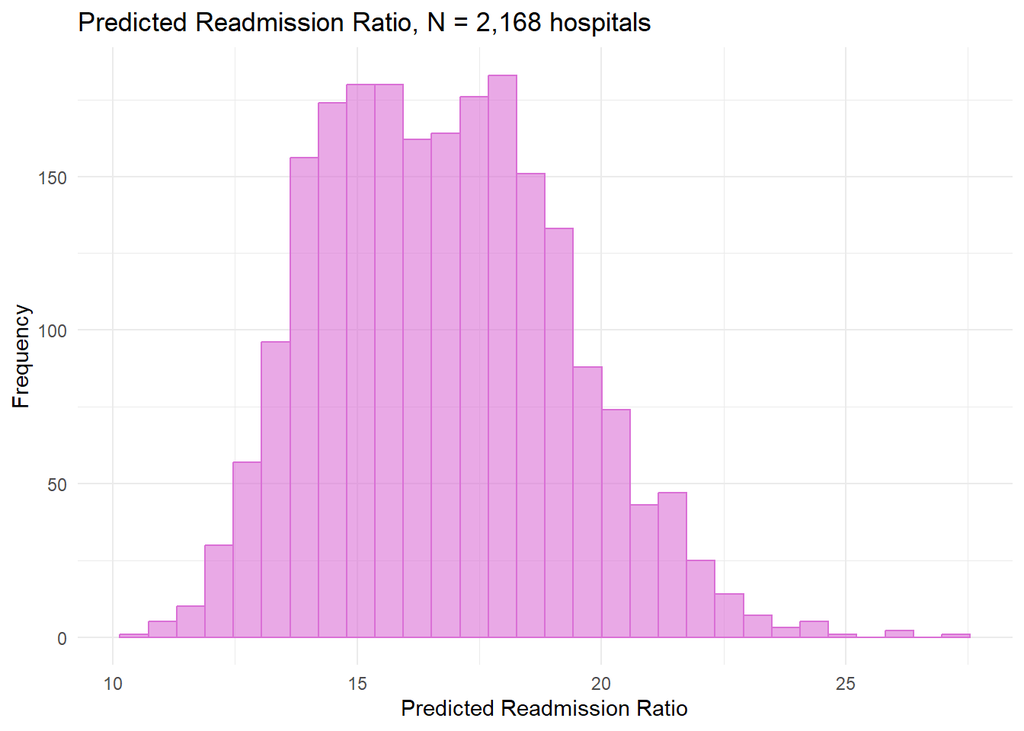

```r
ggplot(readyTrain, aes(x = PredictedReadmissionRate)) +
  geom_histogram(alpha = 0.6,
                 fill = "orchid",
                 color = "orchid") +
  theme_minimal() +
  labs(title = "Predicted Readmission Ratio, N = 2,168 hospitals",
       y = "Frequency",
       x = "Predicted Readmission Ratio")
```

```r
shapiro.test(readyTrain$PredictedReadmissionRate)
```

```
##
##  Shapiro-Wilk normality test
##
## data:  readyTrain$PredictedReadmissionRate
## W = 0.98877, p-value = 0.00000000000551
```

A Box-Cox transformation is used to manipulate the training data into a more-normal distribution for better model performance.

```r
bc_data <- BoxCoxTrans(readyTrain$PredictedReadmissionRate)
print(paste0("Box-Cox lambda =  ", bc_data$lambda))
```

```
## [1] "Box-Cox lambda =  0"
```

Next, we evaluate how the Box-Cox affected the distribution. We can see that the resulting histogram is much more normalized than what it was previously.

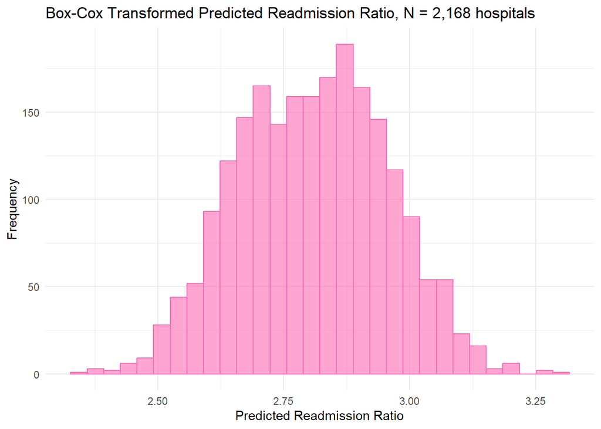

```r
readyTrain$bc_PredictedReadmissionRate <- predict(bc_data, readyTrain$PredictedReadmissionRate)

ggplot(readyTrain, aes(x = bc_PredictedReadmissionRate)) +
  geom_histogram(alpha = 0.6,
                 fill = "hotpink",
                 color = "hotpink") +
  theme_minimal() +
  labs(title = "Box-Cox Transformed Predicted Readmission Ratio, N = 2,168 hospitals",
       y = "Frequency",
       x = "Predicted Readmission Ratio")
```

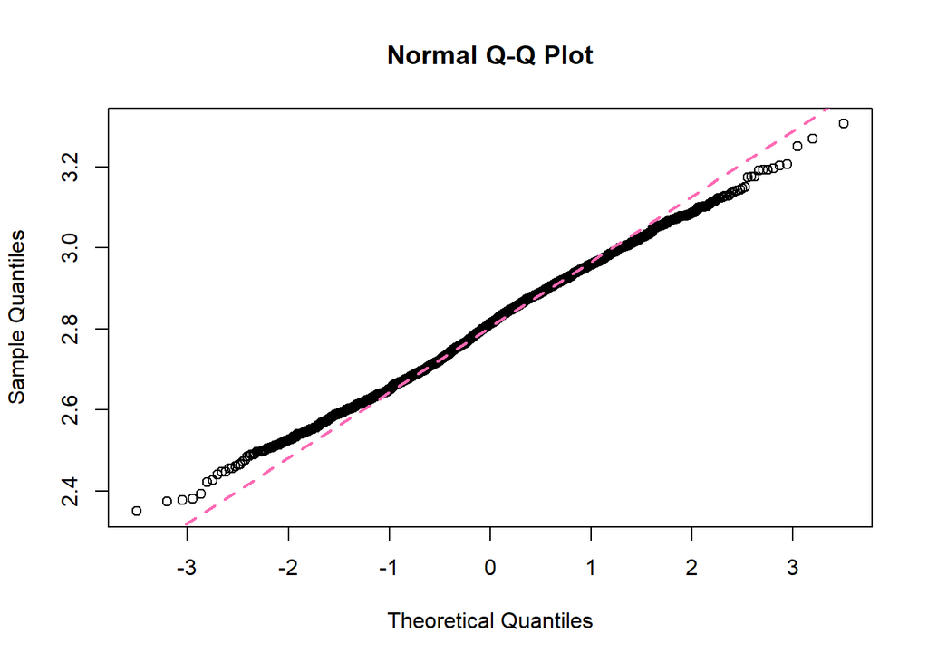

```r
qqnorm(readyTrain$bc_PredictedReadmissionRate)
qqline(readyTrain$bc_PredictedReadmissionRate,
       col = "hotpink", lty = 2, lwd = 2)
```

Apply the same transformation to the test data.

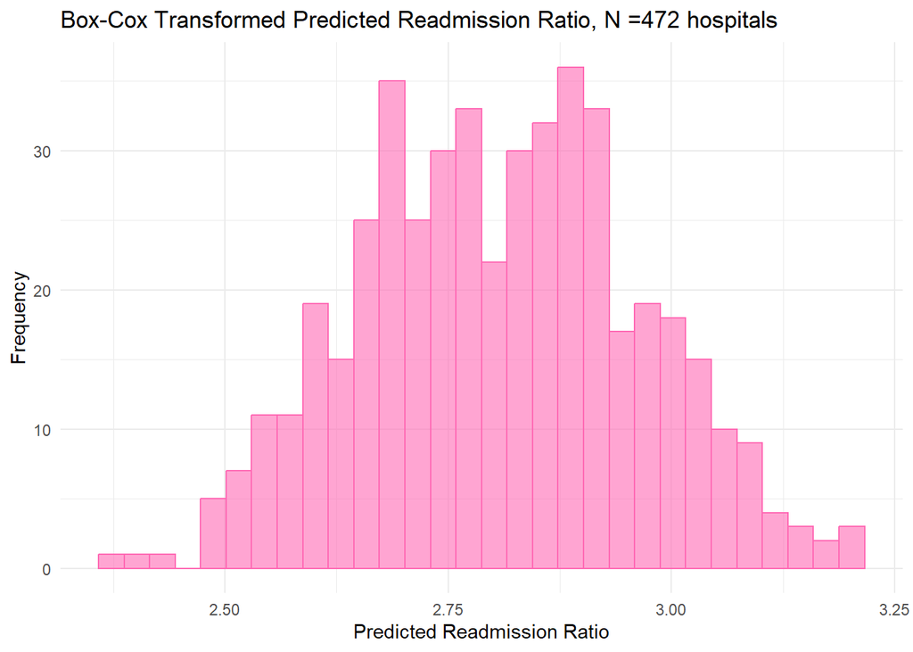

```r
# Your code here.
readyTest$bc_PredictedReadmissionRate <- predict(bc_data, readyTest$PredictedReadmissionRate)

# Make sure to check that your transform looks successful!
ggplot(readyTest, aes(x = bc_PredictedReadmissionRate)) +
  geom_histogram(alpha = 0.6,
                 fill = "hotpink",
                 color = "hotpink") +
  theme_minimal() +
  labs(title = "Box-Cox Transformed Predicted Readmission Ratio, N =472 hospitals",
       y = "Frequency",
       x = "Predicted Readmission Ratio")
```

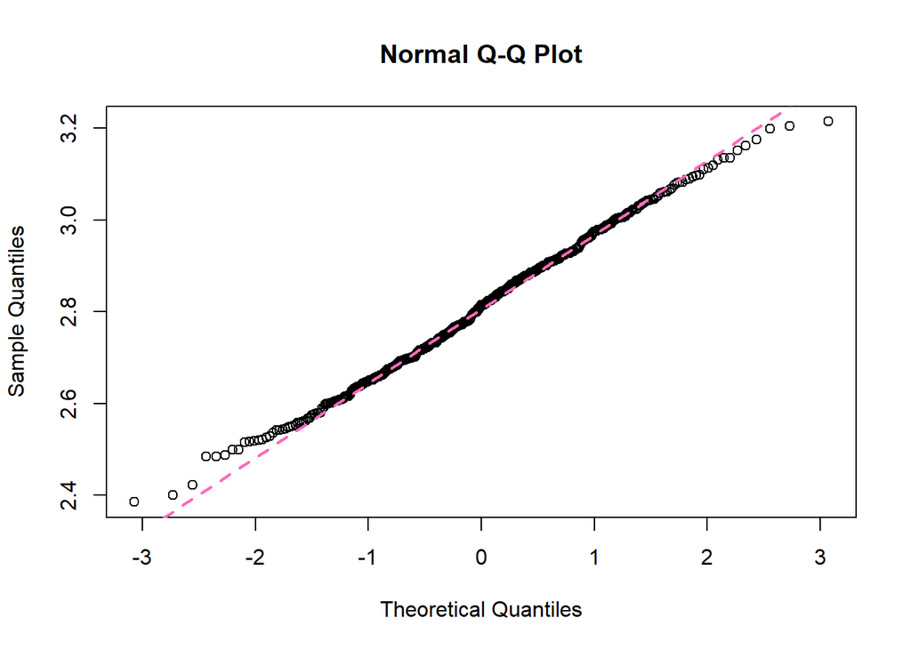

```r
qqnorm(readyTest$bc_PredictedReadmissionRate)
qqline(readyTest$bc_PredictedReadmissionRate,
       col = "hotpink", lty = 2, lwd = 2)
```

Next, we scale the data in both the training & test sets.

```r
readyTrain <- readyTrain %>%
  ## Drop the original target variable
  select(-PredictedReadmissionRate) %>%
  ## Make anything that might still be a factor from encoding is back to number
  mutate_if(is.factor, as.numeric) %>%
  ## Center and scale everything!
  scale(center = TRUE, scale = TRUE) %>%
  data.frame()

readyTest <- readyTest %>%
  ## Drop the original target variable
  select(-PredictedReadmissionRate) %>%
  ## Make anything that might still be a factor from encoding is back to number
  mutate_if(is.factor, as.numeric) %>%
  ## Center and scale everything!
  scale(center = TRUE, scale = TRUE) %>%
  data.frame()
```

# 11 - Checking for multicollinearity

In this next step, we check for colinearity between the variables using a correlation matrix. With this analysis, we can see that there are colinearities - especially between “raw” values and their corresponding “compared to national average” variables.

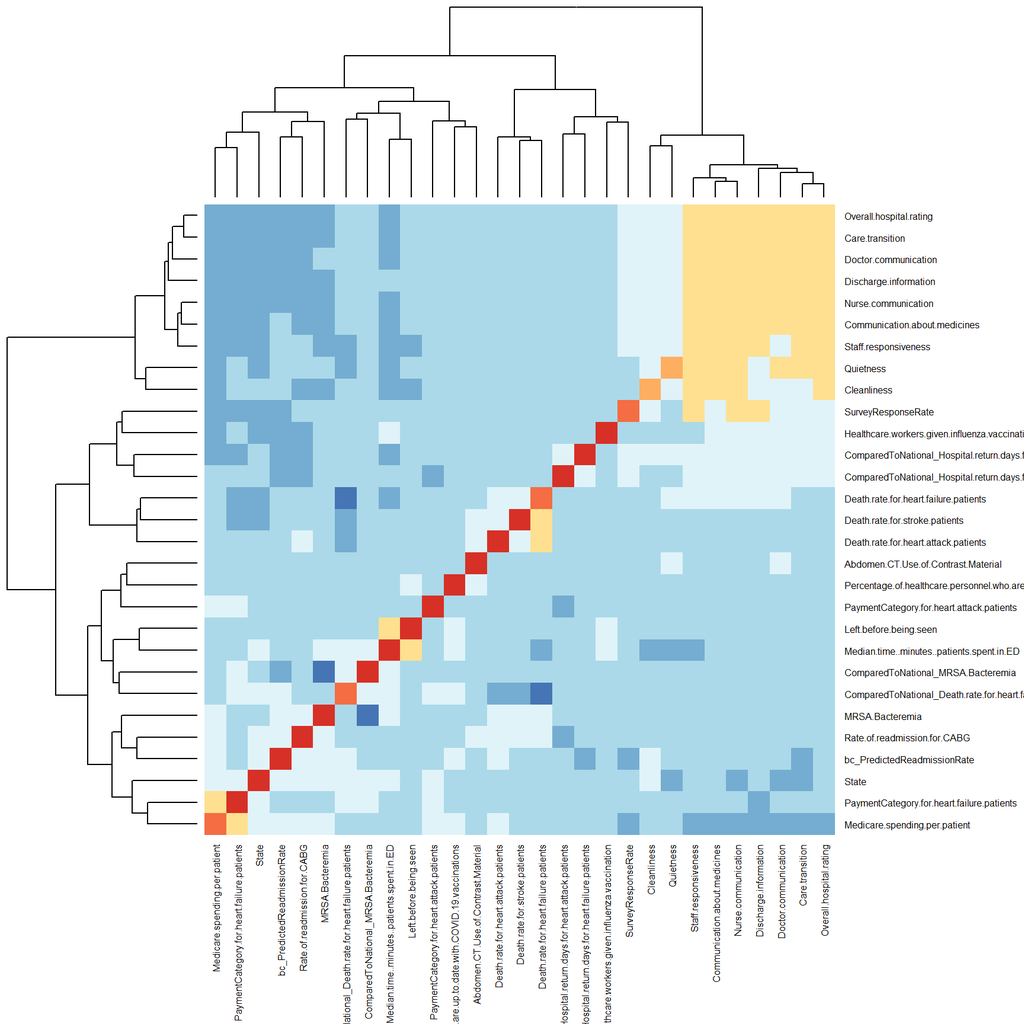

We then drop them from the training & test datasets.

```r
mod <- lm(bc_PredictedReadmissionRate ~ ., data = readyTrain)
## Calculate the VIFs and put into a dataframe to print the table
vifResults <- vif(mod) %>% data.frame
## Change the column names of the dataframe
colnames(vifResults) <- c("VIF")

## Sort by VIF, print the top 15 worst offenders
vifResults %>%
  arrange(desc(VIF)) %>%
  top_n(15) %>%
  ## Pass through kable() to make it pretty
  kable(digits = 2,
    format = "html",
    caption = "Table 7. Top 15 Variance Inflation Factors after multiple linear regression") %>%
    kable_styling(bootstrap_options = c("striped", full_width = F)
)
```

Table 7. Top 15 Variance Inflation Factors after multiple linear regression

|  | VIF |
| --- | --- |
| Nurse.communication | 8.37 |
| Care.transition | 7.09 |
| Overall.hospital.rating | 6.92 |
| Staff.responsiveness | 4.95 |
| Communication.about.medicines | 4.57 |
| Doctor.communication | 3.89 |
| Discharge.information | 3.53 |
| Quietness | 2.26 |
| Death.rate.for.heart.failure.patients | 2.08 |
| ComparedToNational_Death.rate.for.heart.failure.patients | 1.84 |
| Cleanliness | 1.76 |
| Median.time..minutes..patients.spent.in.ED | 1.49 |
| SurveyResponseRate | 1.43 |
| Medicare.spending.per.patient | 1.43 |
| PaymentCategory.for.heart.failure.patients | 1.39 |

```r
## Drop those with VIF over 5
vifOver5 <- vifResults %>% filter(VIF >=5) %>% rownames()
print(vifOver5)
```

```
## [1] "Nurse.communication"     "Care.transition"
## [3] "Overall.hospital.rating"
```

```r
## Now drop them
readyTrain <- readyTrain %>% select(-any_of(vifOver5))
readyTest <- readyTest %>% select(-any_of(vifOver5))
```

# 12 - Final Cleaning Steps

Finally, we will drop columns from our data set which aren’t applicable to the target variable.

```r
readyTrain <- readyTrain %>%
  ## Rename the column we want to keep
  rename(Hospital.return.days.for.heart.attack.patients = ComparedToNational_Hospital.return.days.for.heart.attack.patients) %>%
  rename(Hospital.return.days.for.heart.failure.patients = ComparedToNational_Hospital.return.days.for.heart.failure.patients) %>%
  ## Drop all the other columns
  select(-contains("Compared"), -contains("PaymentCategory"), -SurveyResponseRate)

readyTest <- readyTest %>%
  ## Rename the column we want to keep
  rename(Hospital.return.days.for.heart.attack.patients = ComparedToNational_Hospital.return.days.for.heart.attack.patients) %>%
  rename(Hospital.return.days.for.heart.failure.patients = ComparedToNational_Hospital.return.days.for.heart.failure.patients) %>%
  ## Drop all the other columns
  select(-contains("Compared"))
```

# 13 - Unsupervised Learning & Segmentation Analysis

Here, we begin to determine which factors are needed to generate an accurate model. First, we use PCA to identify the principal components and how they relate to explaining the variance.

```r
pca <- prcomp(readyTrain)
summary(pca)
```

```
## Importance of components:
##                           PC1     PC2     PC3     PC4     PC5     PC6     PC7
## Standard deviation     2.1266 1.37343 1.27633 1.17339 1.04741 1.00588 0.98612
## Proportion of Variance 0.2154 0.08982 0.07757 0.06556 0.05224 0.04818 0.04631
## Cumulative Proportion  0.2154 0.30518 0.38275 0.44832 0.50056 0.54874 0.59504
##                           PC8     PC9    PC10    PC11    PC12    PC13    PC14
## Standard deviation     0.9678 0.94510 0.93561 0.91583 0.90256 0.86502 0.81756
## Proportion of Variance 0.0446 0.04253 0.04168 0.03994 0.03879 0.03563 0.03183
## Cumulative Proportion  0.6396 0.68218 0.72386 0.76380 0.80259 0.83822 0.87005
##                           PC15    PC16    PC17    PC18    PC19   PC20    PC21
## Standard deviation     0.76473 0.70794 0.70073 0.67614 0.52353 0.4979 0.41567
## Proportion of Variance 0.02785 0.02387 0.02338 0.02177 0.01305 0.0118 0.00823
## Cumulative Proportion  0.89790 0.92177 0.94515 0.96692 0.97997 0.9918 1.00000
```

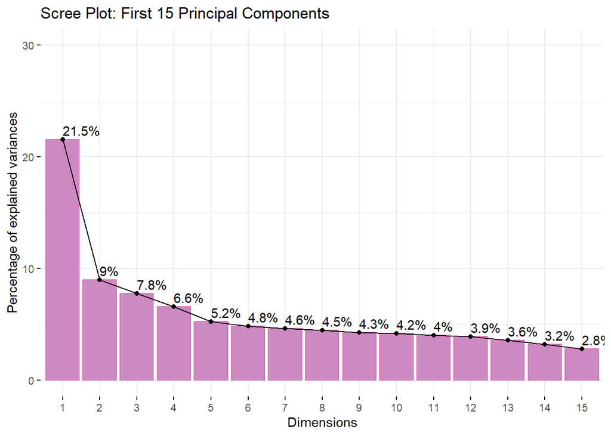

```r
## Show the scree plot
fviz_screeplot(pca,
         addlabels = TRUE,
         ylim = c(0, 30),
         ncp = 15,
         barfill = prettyPurples[13],
         barcolor = prettyPurples[15],
         main = "Scree Plot: First 15 Principal Components")
```

Next, we’ll take a look at the most variance-contributing PCs via two biplots (heart attack & heart failure). The biplots show no discernible direction of the variables in relation to the return days metrics.

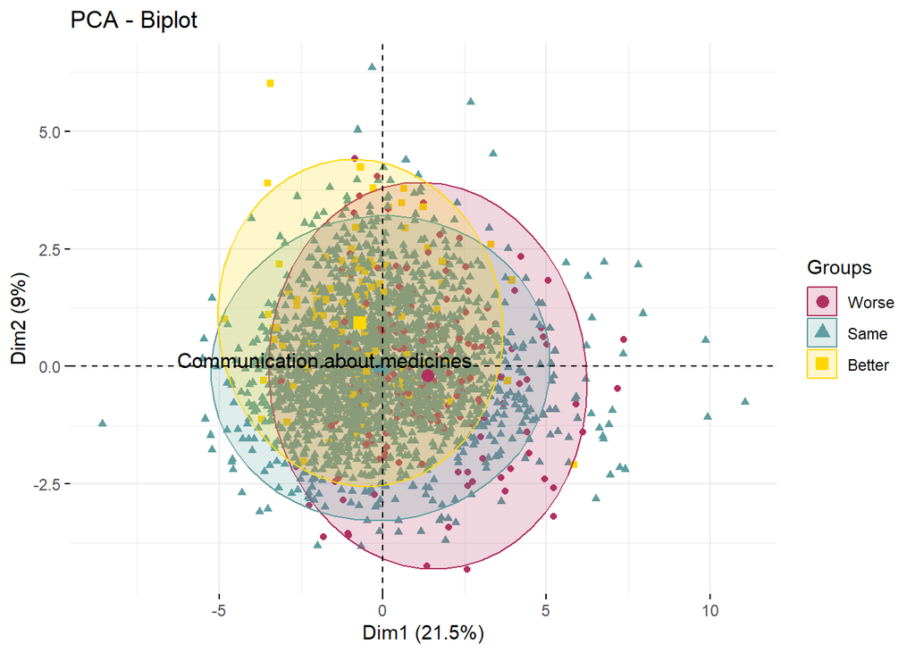

```r
returnHospitalHeartAttackComparison <- factor(readyTrain$Hospital.return.days.for.heart.attack.patients,
                                   labels = c("Worse", "Same", "Better"))

## Now show the biplot
fviz_pca_biplot(pca,
             palette = c("maroon", "cadetblue", "gold"),
             label = "var",
             geom = "point",
             geom.var = "text",
             addEllipses = TRUE,
             ellipse.alpha = 0.2,              ## Change alpha 0-1
             col = "black",
             col.var = "black",
             habillage = returnHospitalHeartAttackComparison,
             select.var = list(contrib = 1),
             repel = T)
```

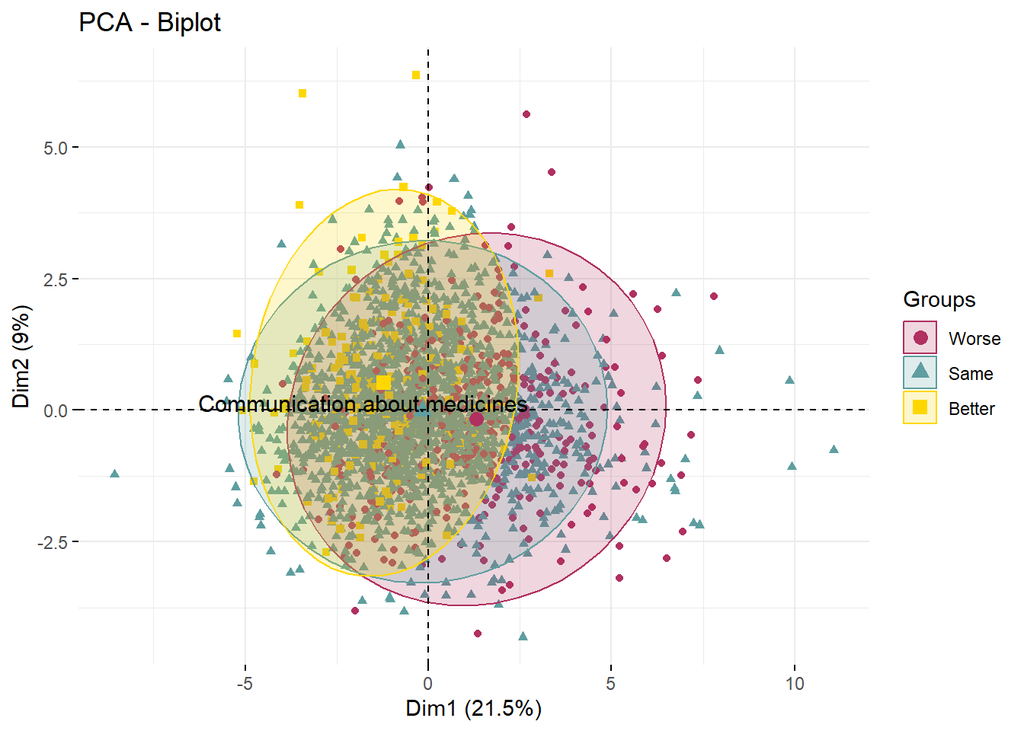

```r
returnHospitalHeartFailureComparison <- factor(readyTrain$Hospital.return.days.for.heart.failure.patients,
                                   labels = c("Worse", "Same", "Better"))

## Now show the biplot
fviz_pca_biplot(pca,
             palette = c("maroon", "cadetblue", "gold"),
             label = "var",
             geom = "point",
             geom.var = "text",
             addEllipses = TRUE,
             ellipse.alpha = 0.2,              ## Change alpha 0-1
             col = "black",
             col.var = "black",
             habillage = returnHospitalHeartFailureComparison,
             select.var = list(contrib = 1),
             repel = T)
```

Next, we’ll view what data points comprise the different components. We see that communication about medicines has a decent amount of inclusion in PC 1&2, but only ~13%.

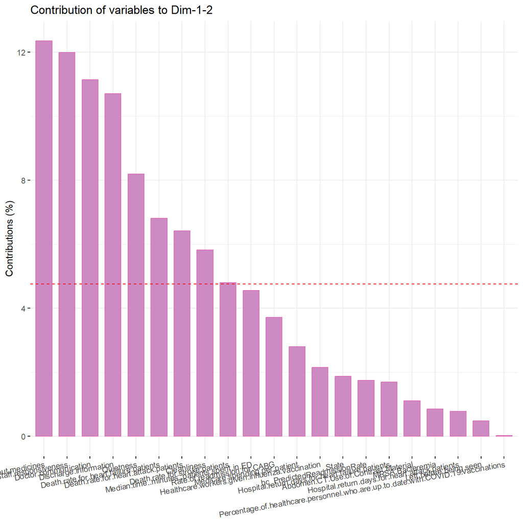

Next, we’ll evaluate the clusters the k-means algorithm is able to generate and attempt to identify the optimal k value. Here, we only evaluate up to k=13.

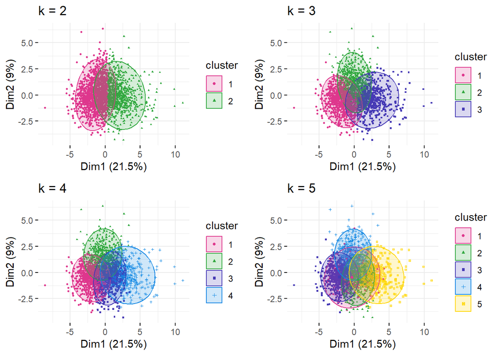

```
## Too few points to calculate an ellipse
## Too few points to calculate an ellipse
```

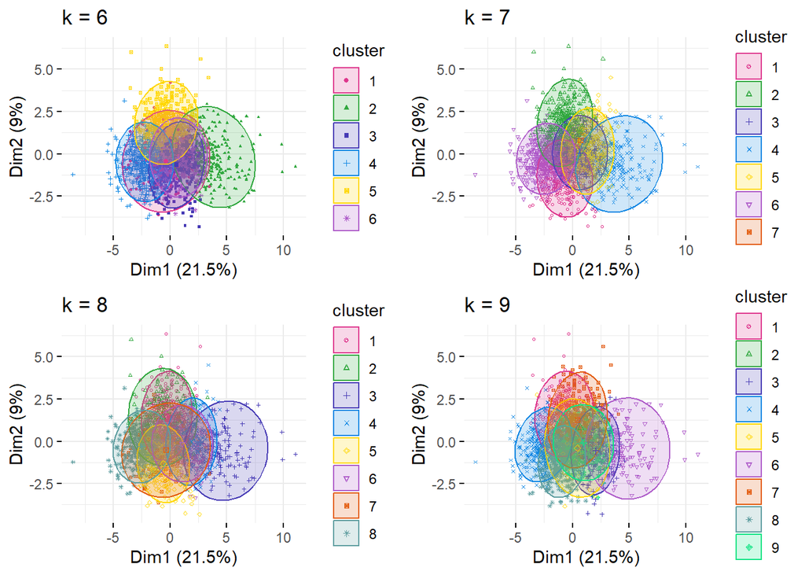

```
## Too few points to calculate an ellipse
## Too few points to calculate an ellipse
```

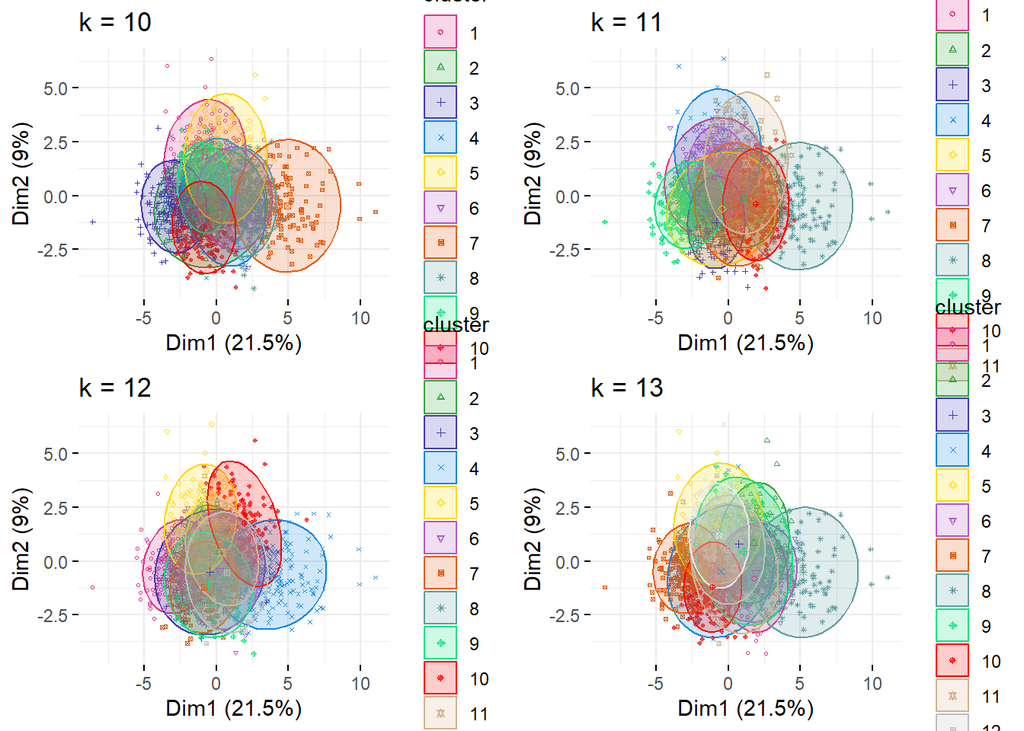

Another way we can evaluate the optimal k value is via the WSS (within sum of squares) method.

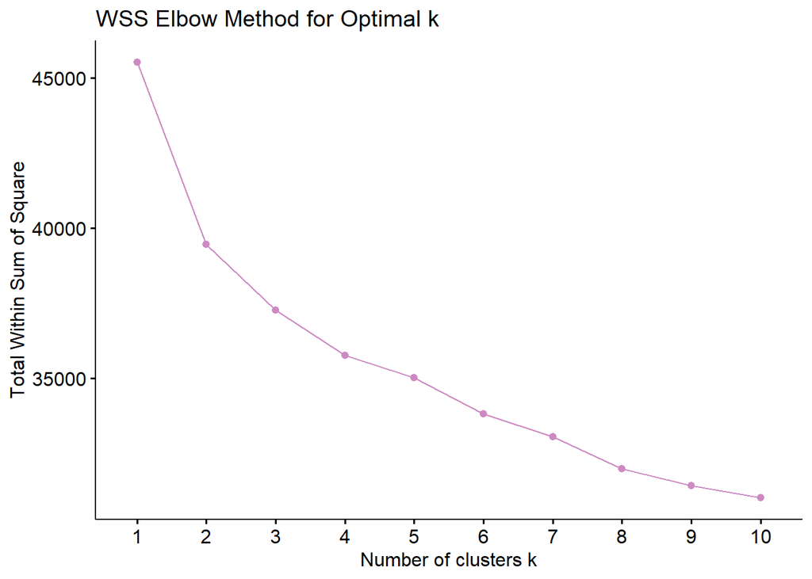

Figure 14. WSS Scree plot for k-means

Both of the previous k-means clustering results rely on heuristics to determine optimal k. In the silhouette method below, we can capture a concrete value of optimal k, which in this case is 2. We then set this optimal value for future use.

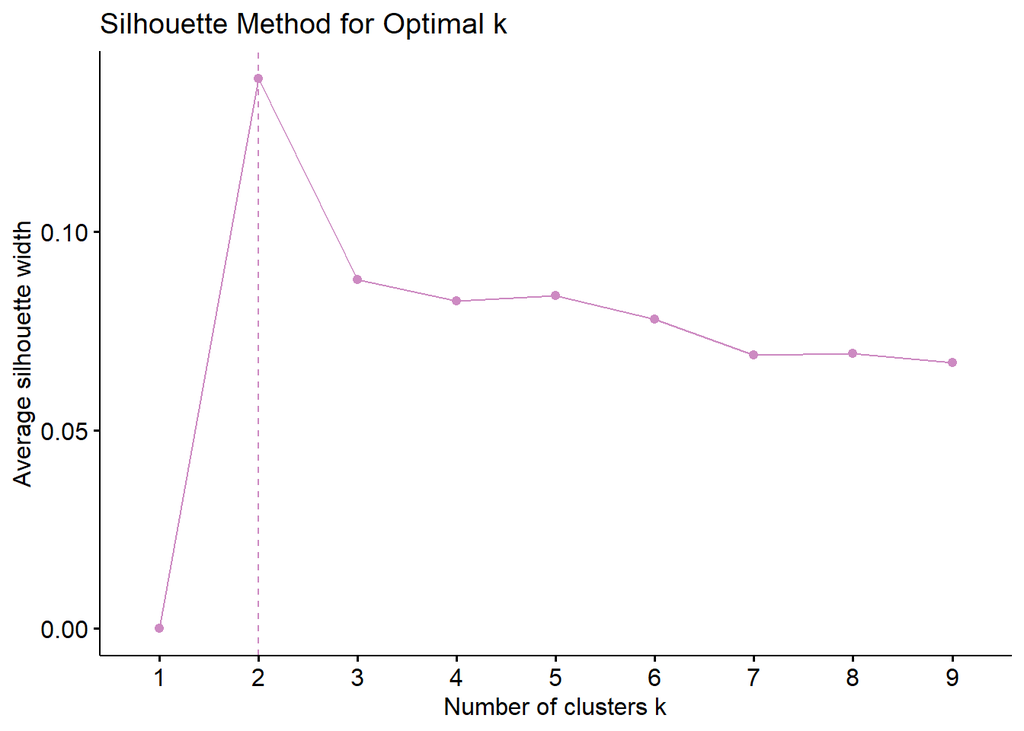

Figure 14. Silhouette Plot for k-means

Now that we have found the optimal number of clusters (2), let’s organize the data into those clusters. We can then evaluate what each cluster predicts for its readmission rate. Below, we show boxplots comparing the two clusters and their outcomes. We can see that there is only a slight improvement between clusters in terms of predicted readmission rate.

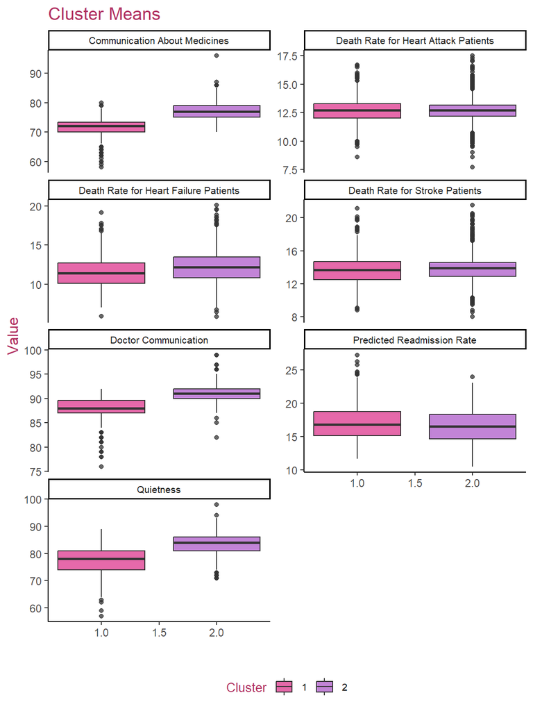

```r
set.seed(1)

## generate kmeans clustering results using kmeans function
kmeansResult <- kmeans(readyTrain,
                         centers = k,      ## k is the optimal number of clusters
                         nstart = 50,
                         iter.max = 1000,
                         algorithm = "MacQueen")

## create a new dataframe named kmeansTrain that is the result of the following expression
kmeansTrain <- imputedTrain %>%
  ## Rename the column we want to keep
  rename(
      HeartAttack.Hospital.Return.Days = `ComparedToNational_Hospital return days for heart attack patients`,
      HeartFailure.Hospital.Return.Days = `ComparedToNational_Hospital return days for heart failure patients`
  ) %>%
  ## select only columns that are not in vifOver5 and do not contain "Compared" and do not contain "PaymentCategory" and not the column SurveyResponseRate
  select(-any_of(vifOver5), -contains("Compared"), -contains("PaymentCategory"), -SurveyResponseRate) %>%
  ## add two columns:
  ## - the cluster
  ## - capture the categorical variable as a numeric
  mutate(
      Cluster = kmeansResult$cluster,
      HeartAttack.Hospital.Return.Days = as.numeric(
        if_else(HeartAttack.Hospital.Return.Days == "1", 1,
           if_else(HeartAttack.Hospital.Return.Days == "0", 0, -1))
        ),
      HeartFailure.Hospital.Return.Days = as.numeric(
        if_else(HeartFailure.Hospital.Return.Days == "1", 1,
           if_else(HeartFailure.Hospital.Return.Days == "0", 0, -1))
        )
   ) %>%
  ## standardize the column names
  clean_names()

## Using % contribution graph, the order of the top 10:
pcaImportantVars <- factor(
  c(
      "Communication.about.medicines",
      "Doctor.communication",
      "Composite.patient.safety",
      "Quietness",
      "Death.rate.for.heart.failure.patients",
      "Death.rate.for.heart.attack.patients",
      "Death.rate.for.stroke.patients",
      "Predicted.Readmission.Rate"
    )
)

## lowercase all the variables in this list
pcaImportantVars <- tolower(pcaImportantVars)
## replace "." with "_"
pcaImportantVars <- gsub("\\.", "_", pcaImportantVars) %>%
## to title case (first char of each word capitalized)
  to_any_case("title")

## output to R the following expression
kmeansTrain %>%
  ## update the column names to standardized conventions, using title case
  clean_names(case = "title") %>%
  ## get the cluster from the kmeans data as well as any column within the pca-important var list
  select(Cluster, any_of(pcaImportantVars)) %>%
  ## pivot the data longways, shifting the column names to the measure variable
  pivot_longer(-1, names_to = "Measure", values_to = "Value") %>%
  ## convert the measurement to a factor
  filter(Measure %in% pcaImportantVars) %>%
  ## generate a boxplot that shows the differences between clusters
    ggplot(aes(x = Cluster, y = Value, fill = as.factor(Cluster))) +
    geom_boxplot(alpha=0.75) +
    scale_fill_manual(values = c(skittles[1], skittles[6])) +
    labs(title = "Cluster Means",
         x = "",
         fill = "Cluster") +
    theme_classic() +
    theme(legend.position = "bottom",
        strip.text = element_text(size=8),
        legend.text = element_text(size = 8),
        legend.title = element_text(size = 10),
        title = element_text(size = 12, color = "maroon")) +
    ## facet the boxplots so that each measurement is projected as its own plot
    facet_wrap(~ Measure,
             scales = "free_y",
             ncol = 2)
```

```r
## output to R the following expression
kmeansTrain %>%
  ## rename columns to use the "." formatting
  rename(
    Predicted.Readmission.Rate = predicted_readmission_rate,
    HeartAttack.Hospital.Return.Days = heart_attack_hospital_return_days,
    HeartFailure.Hospital.Return.Days = heart_failure_hospital_return_days
    ) %>%
  ## update the column names to standardized conventions, using title case
  clean_names(case = "title") %>%
  ## get the cluster from the kmeans data as well as any column within the pca-important var list
  select(Cluster, any_of(pcaImportantVars)) %>%
  ## create a summary table that shows the mean / median values of all continuous variables by cluster
  tbl_summary(by = "Cluster",
              statistic = list(all_continuous() ~ c("{mean} ({median})"))) %>%
  modify_header(label ~ "Variable",
                all_stat_cols() ~ "**Cluster {level}**") %>%
  modify_caption("Table 8. Summary Statistics of Important Cluster Variables")
```

Table 8. Summary Statistics of Important Cluster Variables

| Variable | **Cluster 1**<sup>1</sup> | **Cluster 2**<sup>1</sup> |
| --- | --- | --- |
| Communication About Medicines | 71.4 (72.0) | 77.0 (77.0) |
| Doctor Communication | 88.10 (88.00) | 91.30 (91.00) |
| Quietness | 77.6 (78.0) | 83.3 (84.0) |
| Death Rate for Heart Failure Patients | 11.48 (11.40) | 12.21 (12.20) |
| Death Rate for Heart Attack Patients | 12.69 (12.73) | 12.67 (12.71) |
| Death Rate for Stroke Patients | 13.69 (13.70) | 13.86 (13.90) |
| Predicted Readmission Rate | 17.13 (16.79) | 16.51 (16.51) |

<sup>1</sup> Mean (Median)

# 14 - Supervised Learning Methods

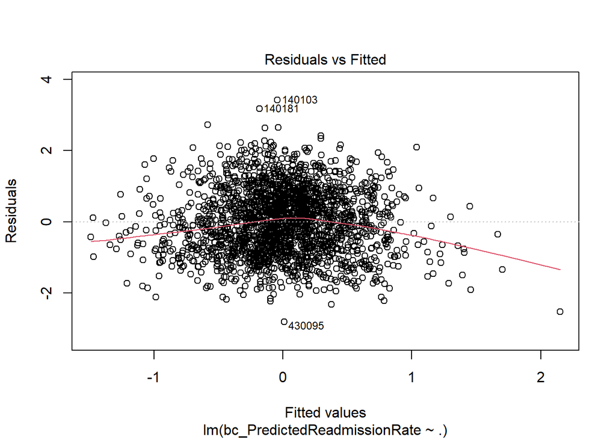

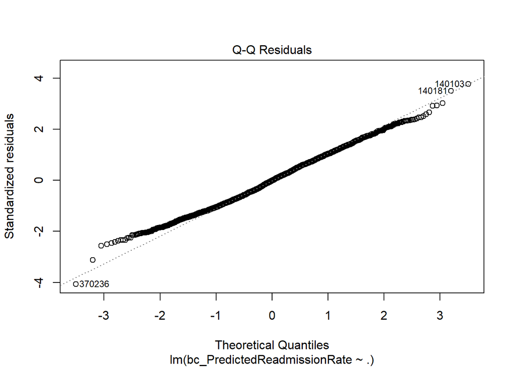

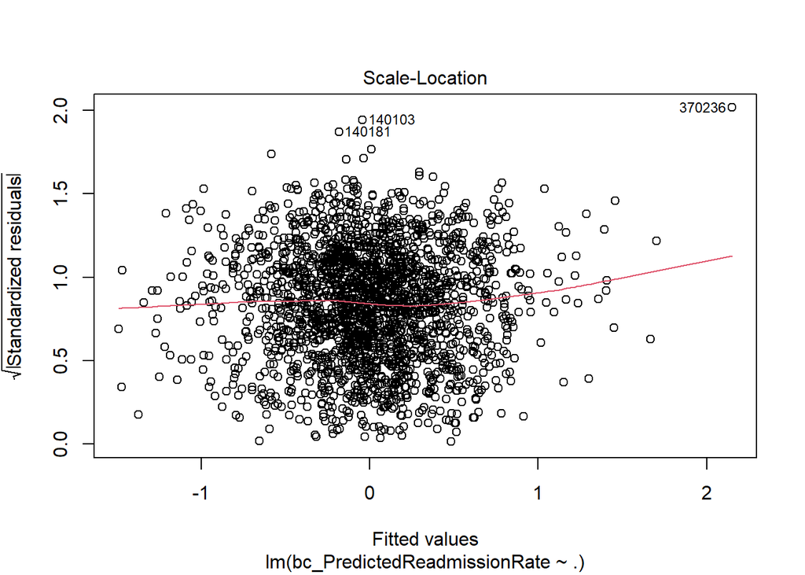

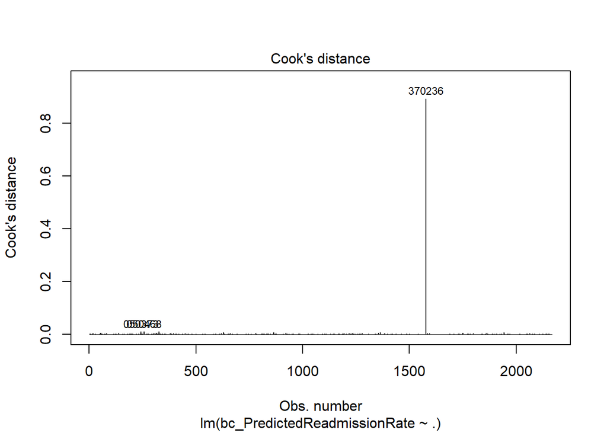

```
##
##  Shapiro-Wilk normality test
##
## data:  residuals(mod)
## W = 0.99573, p-value = 0.000007565
```

```
## [1] 0.1704933
```

Using this model, we’ll try to peel off factors that aren’t significant to the target variable, then make predictions with this trimmed model. We evaluate the predictions graphically. It’s quite obvious the model itself isn’t a great predictor - the error rates along the predictions are very high.

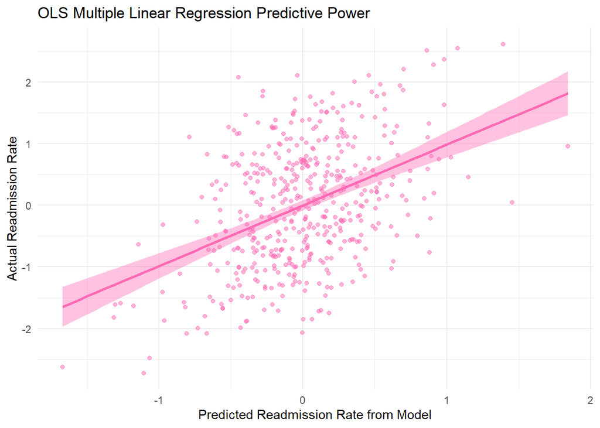

```r
## Perform a backward, stepwise regression to find the most parsimonious model
bestMod <- step(mod,
            direction = "backward",
            trace = FALSE)

## Make the predictions
predictions <- predict(bestMod, newdata = readyTest)

## Add the predictions to the dataset
readyTest$predictions <- predictions

## Graph what the predictions look like relative to the actual data
ggplot(readyTest,
       aes(x = predictions, y = bc_PredictedReadmissionRate)) +
       geom_point(alpha = 0.5, color = "hotpink") +
       geom_smooth(color = "hotpink", fill = "hotpink", se = T, method = "lm") +
  theme_minimal() +
  labs(title = "OLS Multiple Linear Regression Predictive Power",
       x = "Predicted Readmission Rate from Model",
       y = "Actual Readmission Rate")
```

Next, we’ll use the Elastic Net method for fitting a model to our data. First, we’ll set up our CV parameters.

```r
ctrl <- trainControl(method = "repeatedcv",  ## Do repeated CV
                     number = 5,             ## Number of k-folds
                     repeats = 5,            ## Number of repeats
                     search = "grid",        ## Grid search (vs. random)
                     verboseIter = FALSE)    ## Don't show me all the results
```

Using those parameters, we create a grid of alpha & lambda spanning a range of values. We then utilize the CV parameters & the grid of alpha/lambda values in the Elastic Net model generation.

```r
## Create a search grid that allows alpha to range from 0 --> and
## allows lambda to range from 0 --> 5
searchGrid <- expand.grid(.alpha = seq(0, 1, length.out = 10),
                          .lambda = seq(0, 5, length.out = 15))

## Fit the elastic net using the tuning grid and CV scheme laid out
elasticMod <- train(bc_PredictedReadmissionRate ~ .,
                    data = readyTrain,
                    method = "glmnet",
                    tuneGrid = searchGrid,
                    trControl = ctrl)
```

Let’s evaluate the results of Elastic Net and extract the optimal alpha/lambda values. These results are plotted below. We find that the best values of alpha & lambda are both zero.

Table 11. Top Performing Results of the Elastic Net Tuning & 5-fold Repeated Cross-Validation

| alpha | lambda | RMSE | Rsquared | MAE | RMSESD | RsquaredSD | MAESD |
| --- | --- | --- | --- | --- | --- | --- | --- |
| 0.00 | 0.00 | 0.92 | 0.16 | 0.75 | 0.03 | 0.04 | 0.02 |
| 0.11 | 0.00 | 0.92 | 0.16 | 0.75 | 0.03 | 0.04 | 0.02 |
| 0.22 | 0.00 | 0.92 | 0.16 | 0.75 | 0.03 | 0.04 | 0.02 |
| 0.33 | 0.00 | 0.92 | 0.16 | 0.75 | 0.03 | 0.04 | 0.02 |
| 0.44 | 0.00 | 0.92 | 0.16 | 0.75 | 0.03 | 0.04 | 0.02 |
| 0.67 | 0.00 | 0.92 | 0.16 | 0.75 | 0.03 | 0.04 | 0.02 |
| 0.78 | 0.00 | 0.92 | 0.16 | 0.75 | 0.03 | 0.04 | 0.02 |
| 0.56 | 0.00 | 0.92 | 0.16 | 0.75 | 0.03 | 0.04 | 0.02 |
| 0.89 | 0.00 | 0.92 | 0.16 | 0.75 | 0.03 | 0.04 | 0.02 |
| 1.00 | 0.00 | 0.92 | 0.16 | 0.75 | 0.03 | 0.04 | 0.02 |
| 0.00 | 0.36 | 0.92 | 0.16 | 0.76 | 0.03 | 0.03 | 0.02 |
| 0.00 | 0.71 | 0.93 | 0.16 | 0.77 | 0.02 | 0.03 | 0.02 |
| 0.11 | 0.36 | 0.94 | 0.15 | 0.78 | 0.02 | 0.03 | 0.02 |
| 0.00 | 1.07 | 0.94 | 0.15 | 0.78 | 0.02 | 0.03 | 0.02 |
| 0.00 | 1.43 | 0.94 | 0.15 | 0.78 | 0.02 | 0.03 | 0.02 |

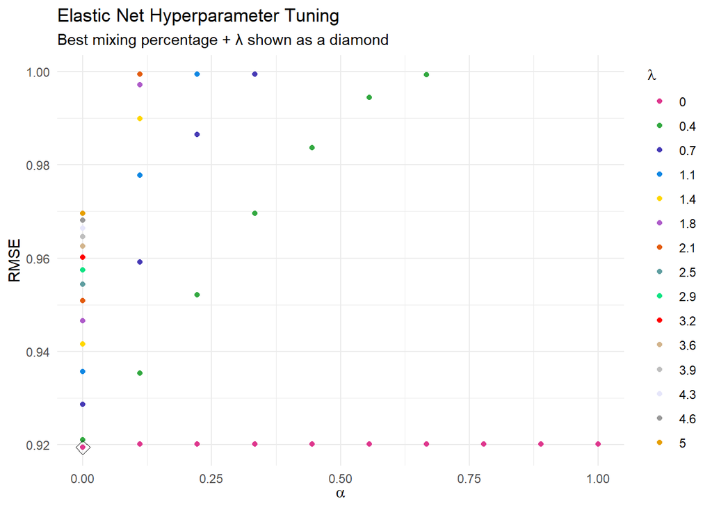

As an example, we extract the features from our Elastic Net model that are most impactful to the observed variance.

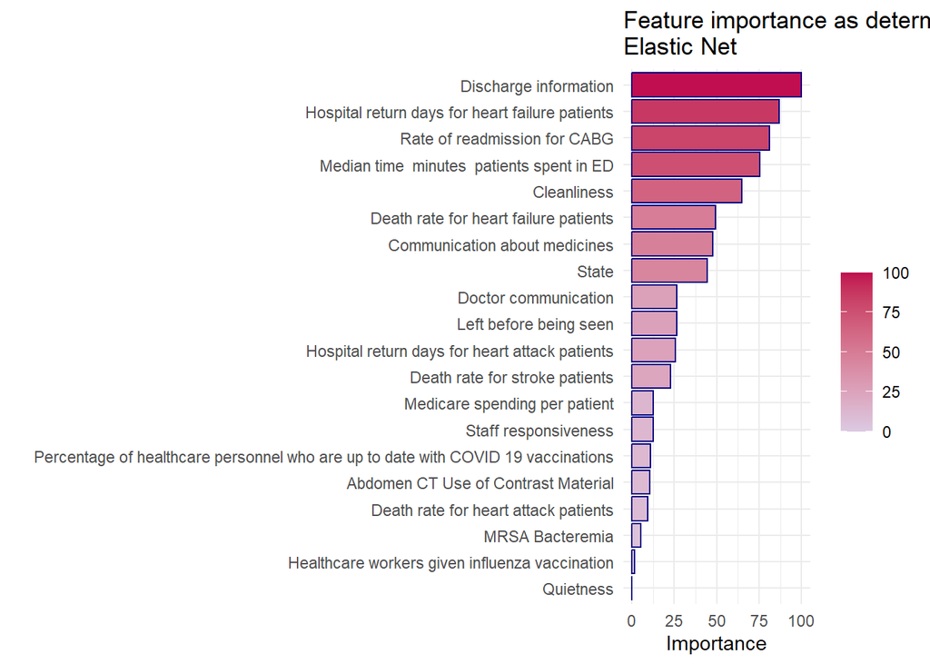

Next, we compare the OLS model against the Elastic Net model. As described in the plot, both these models perform nearly identically.

```r
## Post-resample on OLS
prOLS <- postResample(pred = predict(mod, newdata = readyTest),
                      obs = readyTest$bc_PredictedReadmissionRate)

## Post-resample on Elastic Net
prElastic <- postResample(pred = predict(elasticMod, newdata = readyTest),
                      obs = readyTest$bc_PredictedReadmissionRate)

## Display the output as a table
rbind(prOLS, prElastic) %>%
  kable(digits = 2,
    format = "html",
    caption = "Table 12. Comparison of Model Performance of OLS and Elastic Net Regressions") %>%
    kable_styling(bootstrap_options = c("striped", full_width = F)
)
```

Table 12. Comparison of Model Performance of OLS and Elastic Net Regressions

|  | RMSE | Rsquared | MAE |
| --- | --- | --- | --- |
| prOLS | 0.9 | 0.19 | 0.76 |
| prElastic | 0.9 | 0.19 | 0.76 |

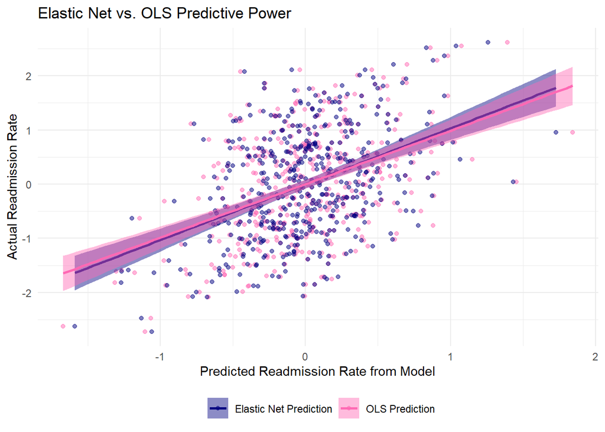

```r
elasticPredictions <- predict(elasticMod, newdata = readyTest)
testingResults <- c(readyTest$predictions,
                    elasticPredictions)
label <- c(rep("OLS Prediction", nrow(readyTest)),
           rep("Elastic Net Prediction", length(elasticPredictions)))
temp <- cbind.data.frame(testingResults, label)
temp$actual <- rep(readyTest$bc_PredictedReadmissionRate, 2)

## Graph what the predictions look like relative to the actual data
ggplot(temp,
       aes(x = testingResults, y = actual, fill = label, color = label)) +
       geom_point(alpha = 0.5) +
       geom_smooth(se = T, method = "lm", alpha = 0.45) +
  scale_color_manual(values = c("navy", "hotpink")) +
  scale_fill_manual(values = c("navy", "hotpink")) +
  theme_minimal() +
  labs(title = "Elastic Net vs. OLS Predictive Power",
       x = "Predicted Readmission Rate from Model",
       y = "Actual Readmission Rate",
       fill = "",
       color = "") +
  theme(legend.position = "bottom")
```

Box, G. E. P., and D. R. Cox. 2018. “An Analysis of Transformations.” *Journal of the Royal Statistical Society: Series B (Methodological)* 26 (2): 211–43. https://doi.org/10.1111/j.2517-6161.1964.tb00553.x.

De Alba, Israel, and Alpesh Amin. 2014. “Pneumonia Readmissions: Risk Factors and Implications.” *Ochsner Journal* 14 (4): 649–54.

R Core Team. 2019. *R: A Language and Environment for Statistical Computing*. Vienna, Austria: R Foundation for Statistical Computing. https://www.R-project.org.

Yeo, In‐Kwon, and Richard A. Johnson. 2000. “A New Family of Power Transformations to Improve Normality or Symmetry.” *Biometrika* 87 (4): 954–59. https://doi.org/10.1093/biomet/87.4.954.

Zou, Hui, and Trevor Hastie. 2005. “Regularization and Variable Selection via the Elastic Net.” *Journal of the Royal Statistical Society Series B: Statistical Methodology* 67 (2): 301–20. https://doi.org/10.1111/j.1467-9868.2005.00503.x.